#### Practice 3 - YELP DATASET

# Pennsylvania State restaurants rating predictions using Natural Language Processing (NLP)

#### Author : David Rivero Berrocoso

# Notebook 2 - Natural Language Processing + Analysing Business Model.

In this notebook we will focus on processing `yelp_academic-dataset_reviews.json`, using Natural Language Processing(NLP) tools to convert the Dataset and, then, carry out an Exploratory Data Analysis of the information contained in the dataset, using geospatial and graphic representations.

**Index**:

> **Dataset foodpen_reviews preprocessing.**
> - Loading & merging.
> - Lemmatization.
> - Sentiment Polarity.
> - 1. Business average sentiment polarity.
> - 1. Sentiment polarity vs stars comparison.
> - Reviews for low-rated restaurants.

> **Pennsylvania Restaurants Dataset Analysis.**
> - Best global restaurants in Pennsylvania.
> - 1. Top 15.
> - 1. Map location.
> - Best italian restaurants in Pennsylvania.
> - 1. Top 15.
> - 1. Map location.
> - Best indian restaurants in Pennsylvania.
> - 1. Top 15.
> - 1. Map location.

> **Business Model.**
> - Restaurant Filtering System.

# Dataset foodpen_reviews preprocessing

```python
import pandas as pd
import nltk
nltk.download('stopwords')
nltk.download('wordnet')
import string
from textblob import TextBlob
import seaborn as sns
import matplotlib.pyplot as plt
import re
from wordcloud import WordCloud
import folium
from folium import Marker
from folium.plugins import MarkerCluster
from geopy.geocoders import Nominatim
import math
```

```python
def preprocess(x):
    x = re.sub('[^a-z\s]', '', x.lower())                  # get rid of noise
    x = [w for w in x.split() if w not in set(stopwords)]  # remove stopwords
    return ' '.join(x) # then join the text again

    # Takes in a string of text, then performs the following:
    # 1. Performs case normalization
    # 2. Remove all punctuation
    # 3. Remove all stopwords
    # 4. Return the cleaned text as a list of words

def sentiment(x):
    sentiment = TextBlob(x)
    return sentiment.sentiment.polarity
```

```python
foodpen = pd.read_csv('../data/raw/foodpen.csv')
foodpen.drop('Unnamed: 0',axis=1,inplace= True)
```

```python
review = []

for chunk in pd.read_json('../data/RAW/YELP/yelp_academic_dataset_review.json', lines=True, chunksize=1000):
    review.append(chunk)

review = pd.concat(review)
review.head(10)
```

|  | review_id | user_id | business_id | stars | useful | funny | cool | text | date |
| --- | --- | --- | --- | --- | --- | --- | --- | --- | --- |
| 0 | KU_O5udG6zpxOg-VcAEodg | mh_-eMZ6K5RLWhZyISBhwA | XQfwVwDr-v0ZS3_CbbE5Xw | 3 | 0 | 0 | 0 | If you decide to eat here, just be aware it is... | 2018-07-07 22:09:11 |
| 1 | BiTunyQ73aT9WBnpR9DZGw | OyoGAe7OKpv6SyGZT5g77Q | 7ATYjTIgM3jUlt4UM3IypQ | 5 | 1 | 0 | 1 | I've taken a lot of spin classes over the year... | 2012-01-03 15:28:18 |
| 2 | saUsX_uimxRlCVr67Z4Jig | 8g_iMtfSiwikVnbP2etR0A | YjUWPpI6HXG530lwP-fb2A | 3 | 0 | 0 | 0 | Family diner. Had the buffet. Eclectic assortm... | 2014-02-05 20:30:30 |
| 3 | AqPFMleE6RsU23_auESxiA | _7bHUi9Uuf5__HHc_Q8guQ | kxX2SOes4o-D3ZQBkiMRfA | 5 | 1 | 0 | 1 | Wow! Yummy, different, delicious. Our favo... | 2015-01-04 00:01:03 |
| 4 | Sx8TMOWLNuJBWer-0pcmoA | bcjbaE6dDog4jkNY91ncLQ | e4Vwtrqf-wpJfwesgvdgxQ | 4 | 1 | 0 | 1 | Cute interior and owner (?) gave us tour of up... | 2017-01-14 20:54:15 |
| 5 | JrIxlS1TzJ-iCu79ul40cQ | eUta8W_HdHMXPzLBBZhL1A | 04UD14gamNjLY0IDYVhHJg | 1 | 1 | 2 | 1 | I am a long term frequent customer of this est... | 2015-09-23 23:10:31 |
| 6 | 6AxgBCNX_PNTOxmbRSwcKQ | r3zeYsv1XFBRA4dJpL78cw | gmjsEdUsKpj9Xxu6pdjH0g | 5 | 0 | 2 | 0 | Loved this tour! I grabbed a groupon and the p... | 2015-01-03 23:21:18 |
| 7 | _ZeMknuYdlQcUqng_Im3yg | yfFzsLmaWF2d4Sr0UNbBgg | LHSTtnW3YHCeUkRDGyJOyw | 5 | 2 | 0 | 0 | Amazingly amazing wings and homemade bleu chee... | 2015-08-07 02:29:16 |
| 8 | ZKvDG2sBvHVdF5oBNUOpAQ | wSTuiTk-sKNdcFyprzZAjg | B5XSoSG3SfvQGtKEGQ1tSQ | 3 | 1 | 1 | 0 | This easter instead of going to Lopez Lake we ... | 2016-03-30 22:46:33 |
| 9 | pUycOfUwM8vqX7KjRRhUEA | 59MxRhNVhU9MYndMkz0wtw | gebiRewfieSdtt17PTW6Zg | 3 | 0 | 0 | 0 | Had a party of 6 here for hibachi. Our waitres... | 2016-07-25 07:31:06 |

```python
review_dict = {
    'review_id': 'string, 22 character unique review id',
    'user_id': 'string, 22 character unique user id, maps to the user in user.json',
    'business_id': 'string, 22 character business id, maps to business in business.json',
    'stars': 'integer, star rating',
    'date': 'string, date formatted YYYY-MM-DD',
    'text': 'string, the review itself',
    'useful': 'integer, number of useful votes received',
    'funny': 'integer, number of funny votes received',
    'cool': 'integer, number of cool votes received'}
print('variables explanation:', review_dict)
```

```
variables explanation: {'review_id': 'string, 22 character unique review id', 'user_id': 'string, 22 character unique user id, maps to the user in user.json', 'business_id': 'string, 22 character business id, maps to business in business.json', 'stars': 'integer, star rating', 'date': 'string, date …
```

**reviews dataset**

the reviews dataset contains full review text data including the user_id that wrote the review and the business_id the review is written for.

```python
review['date'] = pd.to_datetime(review['date'], format='%Y-%m-%')
review['year'] = review.date.dt.year
```

```python
foodpen_reviews = pd.merge(foodpen, review, how='inner', on='business_id')
foodpen_reviews.head(15)
```

|  | BusinessAcceptsCreditCards | Caters | Monday | Tuesday | Wednesday | Thursday | Friday | Saturday | Sunday | business_id | ... | category10 | review_id | user_id | stars_y | useful | funny | cool | text | date | year |
| --- | --- | --- | --- | --- | --- | --- | --- | --- | --- | --- | --- | --- | --- | --- | --- | --- | --- | --- | --- | --- | --- |
| 0 | false | false | 7:0-20:0 | 7:0-20:0 | 7:0-20:0 | 7:0-20:0 | 7:0-21:0 | 7:0-21:0 | 7:0-21:0 | MTSW4McQd7CbVtyjqoe9mw | ... | none | BXQcBN0iAi1lAUxibGLFzA | 6_SpY41LIHZuIaiDs5FMKA | 4 | 0 | 0 | 1 | This is nice little Chinese bakery in the hear... | 2014-05-26 01:09:53 | 2014 |
| 1 | false | false | 7:0-20:0 | 7:0-20:0 | 7:0-20:0 | 7:0-20:0 | 7:0-21:0 | 7:0-21:0 | 7:0-21:0 | MTSW4McQd7CbVtyjqoe9mw | ... | none | uduvUCvi9w3T2bSGivCfXg | tCXElwhzekJEH6QJe3xs7Q | 4 | 3 | 1 | 2 | This is the bakery I usually go to in Chinatow... | 2013-10-05 15:19:06 | 2013 |
| 2 | false | false | 7:0-20:0 | 7:0-20:0 | 7:0-20:0 | 7:0-20:0 | 7:0-21:0 | 7:0-21:0 | 7:0-21:0 | MTSW4McQd7CbVtyjqoe9mw | ... | none | a0vwPOqDXXZuJkbBW2356g | WqfKtI-aGMmvbA9pPUxNQQ | 5 | 0 | 0 | 0 | A delightful find in Chinatown! Very clean, an... | 2013-10-25 01:34:57 | 2013 |
| 3 | false | false | 7:0-20:0 | 7:0-20:0 | 7:0-20:0 | 7:0-20:0 | 7:0-21:0 | 7:0-21:0 | 7:0-21:0 | MTSW4McQd7CbVtyjqoe9mw | ... | none | MKNp_CdR2k2202-c8GN5Dw | 3-1va0IQfK-9tUMzfHWfTA | 5 | 5 | 0 | 5 | I ordered a graduation cake for my niece and i... | 2018-05-20 17:58:57 | 2018 |
| 4 | false | false | 7:0-20:0 | 7:0-20:0 | 7:0-20:0 | 7:0-20:0 | 7:0-21:0 | 7:0-21:0 | 7:0-21:0 | MTSW4McQd7CbVtyjqoe9mw | ... | none | D1GisLDPe84Rrk_R4X2brQ | EouCKoDfzaVG0klEgdDvCQ | 4 | 2 | 1 | 1 | HK-STYLE MILK TEA: FOUR STARS\n\nNot quite su... | 2013-10-25 02:31:35 | 2013 |
| 5 | false | false | 7:0-20:0 | 7:0-20:0 | 7:0-20:0 | 7:0-20:0 | 7:0-21:0 | 7:0-21:0 | 7:0-21:0 | MTSW4McQd7CbVtyjqoe9mw | ... | none | _hJu0u6nB-8LIeQJY4Vg4w | KQSRUu4Aapl0hG6eu2v8iw | 4 | 1 | 0 | 0 | This is my favorite bakery in Chinatown! I usu... | 2018-03-17 23:47:25 | 2018 |
| 6 | false | false | 7:0-20:0 | 7:0-20:0 | 7:0-20:0 | 7:0-20:0 | 7:0-21:0 | 7:0-21:0 | 7:0-21:0 | MTSW4McQd7CbVtyjqoe9mw | ... | none | DbARmo95_axUdC9FU8o_Jw | X_DkwPTzdO_VWzUcbUXREg | 3 | 0 | 0 | 0 | so I dropped in to this store since it was the... | 2012-08-16 19:42:17 | 2012 |
| 7 | false | false | 7:0-20:0 | 7:0-20:0 | 7:0-20:0 | 7:0-20:0 | 7:0-21:0 | 7:0-21:0 | 7:0-21:0 | MTSW4McQd7CbVtyjqoe9mw | ... | none | _xRGsS6QGpcD9LQJNtavuw | qUfRCH5NUyRDsJfM6jA5PQ | 4 | 3 | 4 | 10 | Impression: The good thing is that there are l... | 2017-04-20 12:37:09 | 2017 |
| 8 | false | false | 7:0-20:0 | 7:0-20:0 | 7:0-20:0 | 7:0-20:0 | 7:0-21:0 | 7:0-21:0 | 7:0-21:0 | MTSW4McQd7CbVtyjqoe9mw | ... | none | TLeFbl_5Cb1wcuaeQKX1ew | gNJNxucGoZ31nlH74EQpPg | 4 | 0 | 0 | 0 | Best egg tarts? \n\nI was lucky to get them fr... | 2014-02-25 14:41:08 | 2014 |
| 9 | false | false | 7:0-20:0 | 7:0-20:0 | 7:0-20:0 | 7:0-20:0 | 7:0-21:0 | 7:0-21:0 | 7:0-21:0 | MTSW4McQd7CbVtyjqoe9mw | ... | none | PXMn65bN0byT09LtOXUPuQ | NMOxipsnXc6olWdHYzXiYA | 4 | 0 | 0 | 0 | Little square cakes of happiness with cute bun... | 2012-01-10 02:09:18 | 2012 |
| 10 | false | false | 7:0-20:0 | 7:0-20:0 | 7:0-20:0 | 7:0-20:0 | 7:0-21:0 | 7:0-21:0 | 7:0-21:0 | MTSW4McQd7CbVtyjqoe9mw | ... | none | YY_qfBTB6j6EFhYHWdS7DQ | ZO3Hh2lSFWmiPjDj0Wad5w | 4 | 0 | 0 | 0 | This is my second favorite place for pastries ... | 2011-12-06 03:29:07 | 2011 |
| 11 | false | false | 7:0-20:0 | 7:0-20:0 | 7:0-20:0 | 7:0-20:0 | 7:0-21:0 | 7:0-21:0 | 7:0-21:0 | MTSW4McQd7CbVtyjqoe9mw | ... | none | NwCNci2_9yZecO9bbJG61Q | PoVeK6WYt2r1e3y3y4FwqQ | 4 | 0 | 0 | 1 | This was my and the bf's go-to HK pastry place... | 2013-04-16 23:56:51 | 2013 |
| 12 | false | false | 7:0-20:0 | 7:0-20:0 | 7:0-20:0 | 7:0-20:0 | 7:0-21:0 | 7:0-21:0 | 7:0-21:0 | MTSW4McQd7CbVtyjqoe9mw | ... | none | PY7qyCz43zwDSKaSgaJFTg | _ChgV15rAkH1-FWB8Qd8PQ | 3 | 0 | 0 | 0 | Excellent dim-sum but better get there early. ... | 2014-12-23 21:00:47 | 2014 |
| 13 | false | false | 7:0-20:0 | 7:0-20:0 | 7:0-20:0 | 7:0-20:0 | 7:0-21:0 | 7:0-21:0 | 7:0-21:0 | MTSW4McQd7CbVtyjqoe9mw | ... | none | QvvvwumFGJcwc3-kNQk80Q | uk6po-UUCTk_NvKKgvsOwg | 5 | 0 | 0 | 0 | Nice pastry shop. We went in for bubble tea ... | 2014-10-29 14:38:09 | 2014 |
| 14 | false | false | 7:0-20:0 | 7:0-20:0 | 7:0-20:0 | 7:0-20:0 | 7:0-21:0 | 7:0-21:0 | 7:0-21:0 | MTSW4McQd7CbVtyjqoe9mw | ... | none | 0__mRlq8zHkil4c99Jn_4A | ouODopBKF3AqfCkuQEnrDg | 4 | 5 | 1 | 4 | 3 pastries for $1.25 after 7:00 pm! I love co... | 2010-10-25 03:52:44 | 2010 |

15 rows × 38 columns

#### Text **lemmatization** to transform the text and to ease its processing.

```python
#Lemmatization
from textblob import Word
foodpen_reviews['text'] = foodpen_reviews['text'].apply(lambda x: " ".join([Word(word).lemmatize() for word in x.split()]))
foodpen_reviews['text'].head()
```

```
0    This is nice little Chinese bakery in the hear...
1    This is the bakery I usually go to in Chinatow...
2    A delightful find in Chinatown! Very clean, an...
3    I ordered a graduation cake for my niece and i...
4    HK-STYLE MILK TEA: FOUR STARS Not quite sure w...
Name: text, dtype: object
```

#### *Sentiment polarity*

Now we use the library TEXTBLOB. Textblob is a Python NLP library that uses a natural language toolkit (NLTK). It uses NLTK because it is simple, easy to deploy, will use up fewer resources, gives dependency parsing, and can be used even for small applications. We will use it to calculate sentiment polarity, this is an interpretation of the text of every review and estimates how positive(1) or negative(-1) this review is.

- https://www.topcoder.com/thrive/articles/getting-started-with-textblob-for-sentiment-analysis

```python
%%time
i = nltk.corpus.stopwords.words('english') # find out which stopwords need to remove. We'll use english stopwords.
j = list(string.punctuation) # punctuations to remove

# finally let's combine all of these
stopwords = set(i).union(j)
foodpen_reviews['text_clear'] = foodpen_reviews['text'].apply(preprocess)
```

```
CPU times: total: 1min 50s
Wall time: 1min 52s
```

```python
foodpen_reviews['senti_polarity'] = foodpen_reviews['text_clear'].apply(sentiment)
foodpen_reviews
```

|  | BusinessAcceptsCreditCards | Caters | Monday | Tuesday | Wednesday | Thursday | Friday | Saturday | Sunday | business_id | ... | user_id | stars_y | useful | funny | cool | text | date | year | text_clear | senti_polarity |
| --- | --- | --- | --- | --- | --- | --- | --- | --- | --- | --- | --- | --- | --- | --- | --- | --- | --- | --- | --- | --- | --- |
| 0 | false | false | 7:0-20:0 | 7:0-20:0 | 7:0-20:0 | 7:0-20:0 | 7:0-21:0 | 7:0-21:0 | 7:0-21:0 | MTSW4McQd7CbVtyjqoe9mw | ... | 6_SpY41LIHZuIaiDs5FMKA | 4 | 0 | 0 | 1 | This is nice little Chinese bakery in the hear... | 2014-05-26 01:09:53 | 2014 | nice little chinese bakery heart philadelphias... | 0.232292 |
| 1 | false | false | 7:0-20:0 | 7:0-20:0 | 7:0-20:0 | 7:0-20:0 | 7:0-21:0 | 7:0-21:0 | 7:0-21:0 | MTSW4McQd7CbVtyjqoe9mw | ... | tCXElwhzekJEH6QJe3xs7Q | 4 | 3 | 1 | 2 | This is the bakery I usually go to in Chinatow... | 2013-10-05 15:19:06 | 2013 | bakery usually go chinatown decent variety bun... | 0.094872 |
| 2 | false | false | 7:0-20:0 | 7:0-20:0 | 7:0-20:0 | 7:0-20:0 | 7:0-21:0 | 7:0-21:0 | 7:0-21:0 | MTSW4McQd7CbVtyjqoe9mw | ... | WqfKtI-aGMmvbA9pPUxNQQ | 5 | 0 | 0 | 0 | A delightful find in Chinatown! Very clean, an... | 2013-10-25 01:34:57 | 2013 | delightful find chinatown clean kind service e... | 0.659524 |
| 3 | false | false | 7:0-20:0 | 7:0-20:0 | 7:0-20:0 | 7:0-20:0 | 7:0-21:0 | 7:0-21:0 | 7:0-21:0 | MTSW4McQd7CbVtyjqoe9mw | ... | 3-1va0IQfK-9tUMzfHWfTA | 5 | 5 | 0 | 5 | I ordered a graduation cake for my niece and i... | 2018-05-20 17:58:57 | 2018 | ordered graduation cake niece came absolutely ... | 0.575000 |
| 4 | false | false | 7:0-20:0 | 7:0-20:0 | 7:0-20:0 | 7:0-20:0 | 7:0-21:0 | 7:0-21:0 | 7:0-21:0 | MTSW4McQd7CbVtyjqoe9mw | ... | EouCKoDfzaVG0klEgdDvCQ | 4 | 2 | 1 | 1 | HK-STYLE MILK TEA: FOUR STARS Not quite sure w... | 2013-10-25 02:31:35 | 2013 | hkstyle milk tea four stars quite sure two sai... | 0.162063 |
| ... | ... | ... | ... | ... | ... | ... | ... | ... | ... | ... | ... | ... | ... | ... | ... | ... | ... | ... | ... | ... | ... |
| 901979 | true | true | 11:0-22:0 | 11:0-22:0 | NaN | 11:0-22:0 | 11:0-2:0 | 11:0-2:0 | 11:0-22:0 | WnT9NIzQgLlILjPT0kEcsQ | ... | 6nF5PT1c0dF6EpOgQdF2tw | 5 | 0 | 0 | 0 | Ordered delivery for some taco on a Saturday n... | 2020-12-06 00:19:29 | 2020 | ordered delivery taco saturday night food arri... | 0.303704 |
| 901980 | true | true | 11:0-22:0 | 11:0-22:0 | NaN | 11:0-22:0 | 11:0-2:0 | 11:0-2:0 | 11:0-22:0 | WnT9NIzQgLlILjPT0kEcsQ | ... | 1M78_w4J9f5S8xmUVYyxdQ | 5 | 2 | 1 | 1 | First time trying this restaurant and I had a ... | 2020-11-30 23:19:40 | 2020 | first time trying restaurant good experience o... | 0.358897 |
| 901981 | true | true | 11:0-22:0 | 11:0-22:0 | NaN | 11:0-22:0 | 11:0-2:0 | 11:0-2:0 | 11:0-22:0 | WnT9NIzQgLlILjPT0kEcsQ | ... | B7TD5yTemGv50y4wM2EVNA | 5 | 1 | 1 | 1 | This restaurant is truly amazing!!! The owner ... | 2021-03-27 19:33:29 | 2021 | restaurant truly amazing owner nice ive troubl... | 0.266667 |
| 901982 | true | true | 11:0-22:0 | 11:0-22:0 | NaN | 11:0-22:0 | 11:0-2:0 | 11:0-2:0 | 11:0-22:0 | WnT9NIzQgLlILjPT0kEcsQ | ... | HI8QwhpeP_ZRY5JZy11VDw | 4 | 1 | 0 | 0 | Recently got take out from adelita; they were ... | 2021-02-07 15:09:25 | 2021 | recently got take adelita great super fast ord... | 0.513333 |
| 901983 | true | true | 11:0-22:0 | 11:0-22:0 | NaN | 11:0-22:0 | 11:0-2:0 | 11:0-2:0 | 11:0-22:0 | WnT9NIzQgLlILjPT0kEcsQ | ... | CmR9s-2zH20UkmUt5Qwqnw | 4 | 3 | 1 | 2 | Another pretty good Mexican place to add into ... | 2019-12-23 12:52:26 | 2019 | another pretty good mexican place add mix wont... | 0.245556 |

901984 rows × 40 columns

```python
foodpen_reviews.rename(columns={'stars_x': 'stars_business', 'stars_y': 'stars_review'}, inplace=True)
```

```python
print('n of reviews:', foodpen_reviews.shape[0])
print('n of businesses', foodpen_reviews['business_id'].nunique())
```

```
n of reviews: 901984
n of businesses 10149
```

```python
# foodpen_reviews.to_csv('../data/processed/foodpen_reviews_processed.csv')
```

#### *Business Average Sentiment Polarity*

Now we calculate whe average sentiment polarity for every business (`business_id`), extracted from the text. here are 901,984 rows (1 for every review) and 10149 businesses, so calculating the average we should have 10149 average sentiment polarities.

```python
# ASP = Average Sentmient Polarity
asp = foodpen_reviews.groupby(foodpen_reviews.business_id)['senti_polarity'].mean().sort_values(ascending=True)
asp = asp.reset_index()
```

```python
# we merge senti-polarity df with foodpen from NB1
foodpen_merged = pd.merge(foodpen, asp, how='inner', on='business_id')

        # foodpen_merged.to_csv('../data/RAW/foodpen_merged.csv')
foodpen_merged
```

|  | BusinessAcceptsCreditCards | Caters | Monday | Tuesday | Wednesday | Thursday | Friday | Saturday | Sunday | business_id | ... | category2 | category3 | category4 | category5 | category6 | category7 | category8 | category9 | category10 | senti_polarity |
| --- | --- | --- | --- | --- | --- | --- | --- | --- | --- | --- | --- | --- | --- | --- | --- | --- | --- | --- | --- | --- | --- |
| 0 | false | false | 7:0-20:0 | 7:0-20:0 | 7:0-20:0 | 7:0-20:0 | 7:0-21:0 | 7:0-21:0 | 7:0-21:0 | MTSW4McQd7CbVtyjqoe9mw | ... | food | bubble tea | coffee & tea | bakeries | none | none | none | none | none | 0.277708 |
| 1 | true | true | NaN | NaN | 14:0-22:0 | 16:0-22:0 | 12:0-22:0 | 12:0-22:0 | 12:0-18:0 | mWMc6_wTdE0EUBKIGXDVfA | ... | breweries | food | none | none | none | none | none | none | none | 0.346425 |
| 2 | true | true | NaN | 13:30-22:0 | 13:30-22:0 | 13:30-22:0 | 13:30-23:0 | 13:30-23:0 | 13:30-22:0 | MUTTqe8uqyMdBl186RmNeA | ... | restaurants | japanese | none | none | none | none | none | none | none | 0.344797 |
| 3 | true | true | 11:30-20:30 | 11:30-20:30 | 11:30-20:30 | 11:30-20:30 | 11:30-20:30 | 11:30-20:30 | NaN | ROeacJQwBeh05Rqg7F6TCg | ... | restaurants | none | none | none | none | none | none | none | none | 0.298377 |
| 4 | true | true | 11:0-0:0 | 11:0-0:0 | 11:0-0:0 | 11:0-0:0 | 11:0-1:0 | 11:0-1:0 | 11:0-0:0 | kV_Q1oqis8Qli8dUoGpTyQ | ... | restaurants | none | none | none | none | none | none | none | none | 0.224423 |
| ... | ... | ... | ... | ... | ... | ... | ... | ... | ... | ... | ... | ... | ... | ... | ... | ... | ... | ... | ... | ... | ... |
| 10144 | NaN | NaN | 11:0-0:0 | 11:0-0:0 | 11:0-0:0 | 11:0-0:0 | 11:0-2:0 | 11:0-2:0 | NaN | 2dVJ7R-3JMmu2v4DJYtBbw | ... | cafes | hotels | bars | hotels & travel | restaurants | event planning & services | none | none | none | 0.080090 |
| 10145 | true | true | 6:0-22:0 | 6:0-22:0 | 6:0-22:0 | 6:0-22:0 | 6:0-22:0 | 6:0-22:0 | 6:0-22:0 | Wko0HNelt55ZIp3Dm3eD2g | ... | sandwiches | restaurants | food | grocery | none | none | none | none | none | 0.277500 |
| 10146 | true | true | 10:0-21:0 | 10:0-21:0 | 10:0-21:0 | 10:0-21:0 | 10:0-18:0 | 10:0-16:0 | 10:0-19:0 | wVxXRFf10zTTAs11nr4xeA | ... | specialty food | food | sandwiches | italian | none | none | none | none | none | 0.184634 |
| 10147 | true | true | 0:0-0:0 | 0:0-0:0 | 0:0-0:0 | 0:0-0:0 | 0:0-0:0 | 0:0-0:0 | 0:0-0:0 | l9eLGG9ZKpLJzboZq-9LRQ | ... | sandwiches | convenience stores | coffee & tea | food | none | none | none | none | none | 0.194443 |
| 10148 | true | true | 11:0-22:0 | 11:0-22:0 | NaN | 11:0-22:0 | 11:0-2:0 | 11:0-2:0 | 11:0-22:0 | WnT9NIzQgLlILjPT0kEcsQ | ... | mexican | none | none | none | none | none | none | none | none | 0.334082 |

10149 rows × 30 columns

Now we will see how the relation between stars and sentiment polarity is distributed in order to understand reviewers way of thinking.

In order to do so, we will plot some graphics.

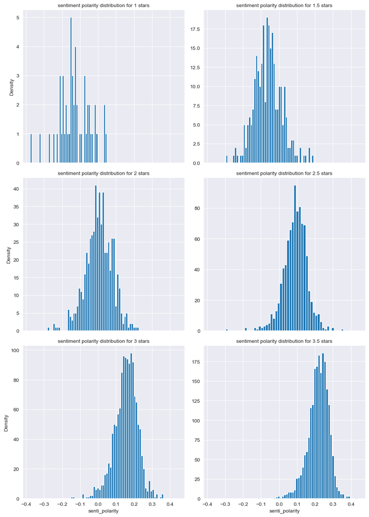

```python
g = sns.FacetGrid(data=foodpen_merged, col='stars', col_wrap=2, col_order=[1, 1.5, 2, 2.5, 3, 3.5], sharex=True, sharey=False)
g.fig.set_size_inches(10, 14)
g.set_titles('sentiment polarity distribution for {col_name} stars')
g.set_xlabels('Sentiment Polarity')
g.set_ylabels('Density')
g.map(plt.hist, 'senti_polarity', bins=50)

#Histograms of text length distributions for each star rating.
#Notice that there is a high number of 4-star and 5-star reviews.
```

### Reviews for low-rated restaurants.

Now we will see which kind of words are used in the lower rated restaurants.

```python
bad_food = foodpen_merged[foodpen_merged['stars'] <= 2]
```

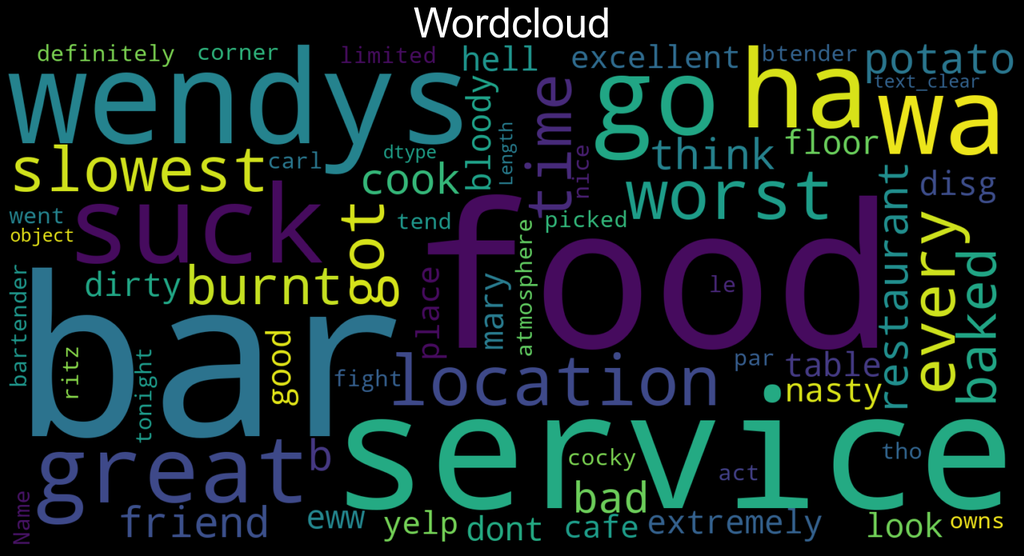

```python
bad_food = pd.merge(foodpen_reviews, bad_food, how='right', on='business_id')
wc = WordCloud(width=1600, height=800, random_state=1, max_words=200000000)
wc.generate(str(bad_food['text_clear']))
plt.figure(figsize=(20,10), facecolor='k')
plt.title("Wordcloud", fontsize=40,color='white')
plt.imshow(wc, interpolation='bilinear')
plt.axis('off')
plt.tight_layout(pad=10)
plt.show()
```

# Pennsylvania Restaurants Dataset Analysis.

#### Best restaurants in Pennsylvania

```python
good_food = foodpen_merged[(foodpen_merged['senti_polarity']>0)&(foodpen_merged['stars']>=3)]
good_food.head(5)
```

|  | BusinessAcceptsCreditCards | Caters | Monday | Tuesday | Wednesday | Thursday | Friday | Saturday | Sunday | business_id | ... | category2 | category3 | category4 | category5 | category6 | category7 | category8 | category9 | category10 | senti_polarity |
| --- | --- | --- | --- | --- | --- | --- | --- | --- | --- | --- | --- | --- | --- | --- | --- | --- | --- | --- | --- | --- | --- |
| 0 | false | false | 7:0-20:0 | 7:0-20:0 | 7:0-20:0 | 7:0-20:0 | 7:0-21:0 | 7:0-21:0 | 7:0-21:0 | MTSW4McQd7CbVtyjqoe9mw | ... | food | bubble tea | coffee & tea | bakeries | none | none | none | none | none | 0.277708 |
| 1 | true | true | NaN | NaN | 14:0-22:0 | 16:0-22:0 | 12:0-22:0 | 12:0-22:0 | 12:0-18:0 | mWMc6_wTdE0EUBKIGXDVfA | ... | breweries | food | none | none | none | none | none | none | none | 0.346425 |
| 2 | true | true | NaN | 13:30-22:0 | 13:30-22:0 | 13:30-22:0 | 13:30-23:0 | 13:30-23:0 | 13:30-22:0 | MUTTqe8uqyMdBl186RmNeA | ... | restaurants | japanese | none | none | none | none | none | none | none | 0.344797 |
| 3 | true | true | 11:30-20:30 | 11:30-20:30 | 11:30-20:30 | 11:30-20:30 | 11:30-20:30 | 11:30-20:30 | NaN | ROeacJQwBeh05Rqg7F6TCg | ... | restaurants | none | none | none | none | none | none | none | none | 0.298377 |
| 4 | true | true | 11:0-0:0 | 11:0-0:0 | 11:0-0:0 | 11:0-0:0 | 11:0-1:0 | 11:0-1:0 | 11:0-0:0 | kV_Q1oqis8Qli8dUoGpTyQ | ... | restaurants | none | none | none | none | none | none | none | none | 0.224423 |

5 rows × 30 columns

```python
best_pen = good_food[['name', 'stars']].astype(str).apply(lambda x: '->Rating: '.join(x), axis=1).tolist()
best_pen
```

```
['st honore pastries->Rating: 4.0',
 'perkiomen valley brewery->Rating: 4.5',
 'tuna bar->Rating: 4.0',
 'bap->Rating: 4.5',
 'ardmore pizza->Rating: 3.5',
 'craft hall->Rating: 3.5',
 'core de roma->Rating: 5.0',
 '39 north taproom & grill->Rating: 4.5',
 'wawa->Rating: 3.0',
 'giant food store->Rating: 3.0',
 'golden chopstick chinese restaurant->Rating: 3.0',
 "rita's italian ice->Rating: 4.0",
 'giant food stores->Rating: 4.0',
 'bagelicious - king of prussia->Rating: 3.5',
 'reanimator coffee->Rating: 4.0',
 'red hook coffee & tea->Rating: 4.5',
 'cvs pharmacy->Rating: 3.0',
 'baltic bakery->Rating: 4.5',
 'brown sugar bakery & cafe->Rating: 4.5',
 'la sponda->Rating: 4.5',
 'federal donuts->Rating: 4.5',
 'fine wine & good spirits->Rating: 3.5',
 'world of beer->Rating: 3.0',
 'snacks by the pound->Rating: 3.5',
 'the love->Rating: 4.0',
 'ryan christopher->Rating: 4.0',
 'liberty city roasters->Rating: 4.5',
 'jong ka jib->Rating: 4.5',
 'marcie blaine->Rating: 3.5',
 'the twisted tail->Rating: 4.0',
 'metro diner->Rating: 3.5',
 "freddy's frozen custard & steakburgers->Rating: 3.5",
 'chick-fil-a->Rating: 4.0',
 'ny bagel & deli shop->Rating: 4.0',
 'olde black horse->Rating: 4.0',
 'none such farm market->Rating: 4.0',
 'la cucina italian eatery->Rating: 4.0',
 'state street kitchen->Rating: 4.5',
 'wawa->Rating: 3.5',
 "nudy's cafe - chadds ford->Rating: 3.5",
```

[output cut: 946 more lines]

```
 'great valley beverage->Rating: 4.0',
 "bella maria's pizzeria->Rating: 3.5",
 'gelato aromi->Rating: 3.0',
 'independence after hours->Rating: 4.5',
 'ardmore farmers market->Rating: 3.5',
 'spirit of philadelphia->Rating: 3.0',
 'c j wok->Rating: 3.0',
 'bob evans->Rating: 3.0',
 'covered bridge coffee roasters->Rating: 5.0',
 'seedling and sage catering co->Rating: 5.0',
 'tony boys->Rating: 4.5',
 'pretty bird coffee->Rating: 4.0',
 "pietro's pizza->Rating: 3.5",
 'southhouse->Rating: 4.5',
 ...]
```

```python
top_restaurants = good_food['business_id'].tolist()
good_food.loc[good_food['business_id'].isin(top_restaurants)].head(5)
```

|  | BusinessAcceptsCreditCards | Caters | Monday | Tuesday | Wednesday | Thursday | Friday | Saturday | Sunday | business_id | ... | category2 | category3 | category4 | category5 | category6 | category7 | category8 | category9 | category10 | senti_polarity |
| --- | --- | --- | --- | --- | --- | --- | --- | --- | --- | --- | --- | --- | --- | --- | --- | --- | --- | --- | --- | --- | --- |
| 0 | false | false | 7:0-20:0 | 7:0-20:0 | 7:0-20:0 | 7:0-20:0 | 7:0-21:0 | 7:0-21:0 | 7:0-21:0 | MTSW4McQd7CbVtyjqoe9mw | ... | food | bubble tea | coffee & tea | bakeries | none | none | none | none | none | 0.277708 |
| 1 | true | true | NaN | NaN | 14:0-22:0 | 16:0-22:0 | 12:0-22:0 | 12:0-22:0 | 12:0-18:0 | mWMc6_wTdE0EUBKIGXDVfA | ... | breweries | food | none | none | none | none | none | none | none | 0.346425 |
| 2 | true | true | NaN | 13:30-22:0 | 13:30-22:0 | 13:30-22:0 | 13:30-23:0 | 13:30-23:0 | 13:30-22:0 | MUTTqe8uqyMdBl186RmNeA | ... | restaurants | japanese | none | none | none | none | none | none | none | 0.344797 |
| 3 | true | true | 11:30-20:30 | 11:30-20:30 | 11:30-20:30 | 11:30-20:30 | 11:30-20:30 | 11:30-20:30 | NaN | ROeacJQwBeh05Rqg7F6TCg | ... | restaurants | none | none | none | none | none | none | none | none | 0.298377 |
| 4 | true | true | 11:0-0:0 | 11:0-0:0 | 11:0-0:0 | 11:0-0:0 | 11:0-1:0 | 11:0-1:0 | 11:0-0:0 | kV_Q1oqis8Qli8dUoGpTyQ | ... | restaurants | none | none | none | none | none | none | none | none | 0.224423 |

5 rows × 30 columns

**Top 15**

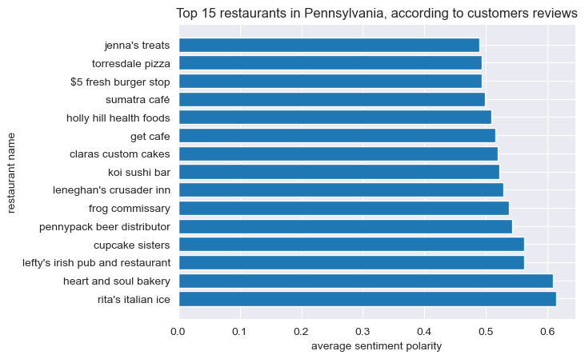

```python
import matplotlib.pyplot as plt
plt.title('Top 15 restaurants in Pennsylvania, according to customers reviews')
plt.xlabel('average sentiment polarity')
plt.ylabel('restaurant name')
good_food_sorted = good_food.sort_values(by='senti_polarity', ascending=False)
good_food_top_15 = good_food_sorted[:15]
plt.barh(good_food_top_15['name'], good_food_top_15['senti_polarity'])
plt.show()
```

**Most used words**: Now we will use the library *Wordcloud* to see which are the most used words in the reviews of the top 15 most rated restaurants:

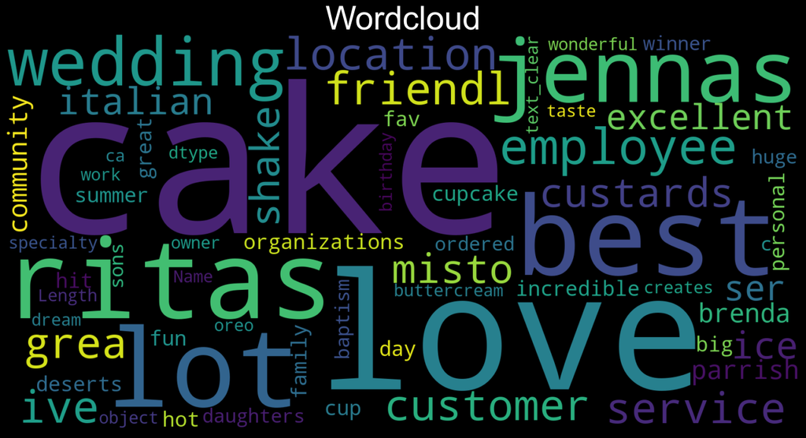

```python
foodpen_reviews_top15 = pd.merge(foodpen_reviews, good_food_top_15, how='right', on='business_id')
wc = WordCloud(width=1600, height=800, random_state=1, max_words=200000000)
wc.generate(str(foodpen_reviews_top15['text_clear']))
plt.figure(figsize=(20,10), facecolor='k')
plt.title("Wordcloud", fontsize=40,color='white')
plt.imshow(wc, interpolation='bilinear')
plt.axis('off')
plt.tight_layout(pad=10)
plt.show()
```

**Map Location**

```python
# first we check Philadelphia coordenates (Pennsylvania coordenates would be more correct but they don't fit good enough)
geolocator = Nominatim(user_agent="my_app")
location = geolocator.geocode("Philadelphia")
print(location.latitude, location.longitude)
```

```
39.9527237 -75.1635262
```

```python
m_1 = folium.Map(location=[39.9527237, -75.1635262], zoom_start=10)

# Add points to the map
for idx, row in good_food_top_15.iterrows():
    Marker([row['latitude'], row['longitude']]).add_to(m_1)

title_html = '''
             <h3 align="center" style="font-size:20px"><b>Top 15 restaurants in Pennsylvania</b></h3>
             '''
m_1.get_root().html.add_child(folium.Element(title_html))

# Display the map
m_1
```

Make this Notebook Trusted to load map: File -> Trust Notebook

[interactive chart not shown]

Now we check best restaurants for particular cuisines...

#### Italian cuisine

```python
italian = 'italian', ' italian'
foodpen_it = good_food.loc[(good_food['category1'].isin(italian)) | (good_food['category2'].isin(italian)) | (good_food['category3'].isin(italian)) |(good_food['category4'].isin(italian)) | (good_food['category5'].isin(italian)) | (good_food['category6'].isin(italian)) | (good_food['category7'].isin(italian)) | (good_food['category8'].isin(italian)) | (good_food['category9'].isin(italian)) | (good_food['category10'].isin(italian))]
```

**Top 15**

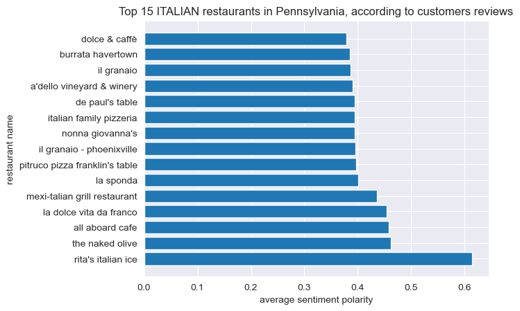

```python
import matplotlib.pyplot as plt
plt.title('Top 15 ITALIAN restaurants in Pennsylvania, according to customers reviews')
plt.xlabel('average sentiment polarity')
plt.ylabel('restaurant name')
foodpen_it_sorted = foodpen_it.sort_values(by='senti_polarity', ascending=False)
foodpen_it_top_15 = foodpen_it_sorted[:15]
plt.barh(foodpen_it_top_15['name'], foodpen_it_top_15['senti_polarity'])
plt.show()
```

**Most used words**: Now we will use the library *Wordcloud* to see which are the most used words in the reviews of the top 15 most rated italian restaurants:

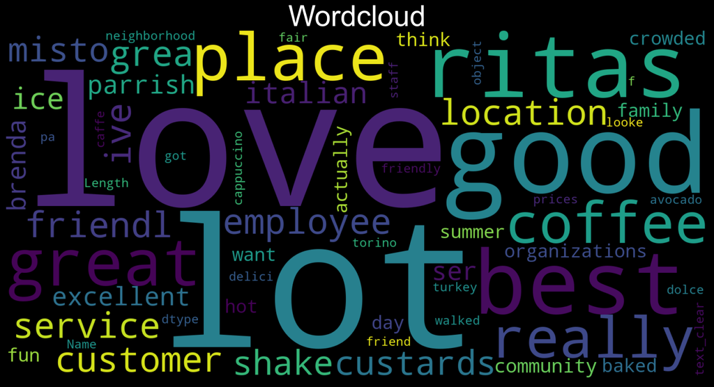

```python
foodpen_reviews_it_top15 = pd.merge(foodpen_reviews, foodpen_it_top_15, how='right', on='business_id')
wc = WordCloud(width=1600, height=800, random_state=1, max_words=200000000)
wc.generate(str(foodpen_reviews_it_top15['text_clear']))
plt.figure(figsize=(20,10), facecolor='k')
plt.title("Wordcloud", fontsize=40,color='white')
plt.imshow(wc, interpolation='bilinear')
plt.axis('off')
plt.tight_layout(pad=10)
plt.show()
```

**Map Location**

```python
m_1 = folium.Map(location=[39.9527237, -75.1635262], tiles='cartodbpositron', zoom_start=9)

# Add points to the map
mc = MarkerCluster()
for idx, row in foodpen_it.iterrows():
    if not math.isnan(row['longitude']) and not math.isnan(row['latitude']):
        mc.add_child(Marker([row['latitude'], row['longitude']]))
m_1.add_child(mc)

title_html = '''
             <h3 align="center" style="font-size:20px"><b>Italian restaurants distribution in Pennsylvania</b></h3>
             '''
m_1.get_root().html.add_child(folium.Element(title_html))

# Display the map
m_1
```

Make this Notebook Trusted to load map: File -> Trust Notebook

[interactive chart not shown]

#### Indian cuisine

```python
indian = 'indian', ' indian'
foodpen_in = good_food.loc[(good_food['category1'].isin(indian)) | (good_food['category2'].isin(indian)) | (good_food['category3'].isin(indian)) |(good_food['category4'].isin(indian)) | (good_food['category5'].isin(indian)) | (good_food['category6'].isin(indian)) | (good_food['category7'].isin(indian)) | (good_food['category8'].isin(indian)) | (good_food['category9'].isin(indian)) | (good_food['category10'].isin(indian))]
```

**Top 15**

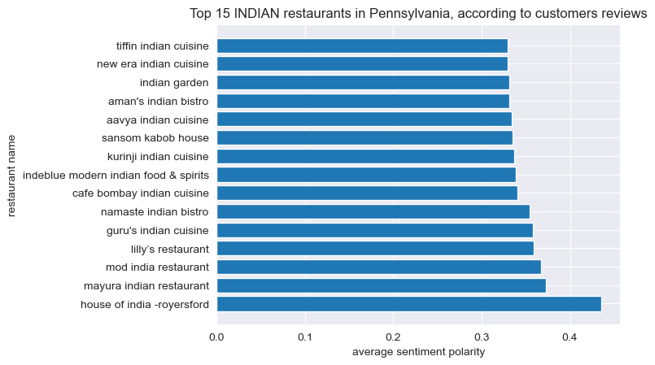

```python
import matplotlib.pyplot as plt
plt.title('Top 15 INDIAN restaurants in Pennsylvania, according to customers reviews')
plt.xlabel('average sentiment polarity')
plt.ylabel('restaurant name')
foodpen_in_sorted = foodpen_in.sort_values(by='senti_polarity', ascending=False)
foodpen_in_top_15 = foodpen_in_sorted[:15]
plt.barh(foodpen_in_top_15['name'], foodpen_in_top_15['senti_polarity'])
plt.show()
```

```python
foodpen_it_top_15
```

|  | BusinessAcceptsCreditCards | Caters | Monday | Tuesday | Wednesday | Thursday | Friday | Saturday | Sunday | business_id | ... | category2 | category3 | category4 | category5 | category6 | category7 | category8 | category9 | category10 | senti_polarity |
| --- | --- | --- | --- | --- | --- | --- | --- | --- | --- | --- | --- | --- | --- | --- | --- | --- | --- | --- | --- | --- | --- |
| 8863 | true | true | 11:0-21:0 | 11:0-21:0 | 11:0-21:0 | 11:0-21:0 | 11:0-21:0 | 11:0-21:0 | 11:0-21:0 | JdCQ3DPoKwSBjB0RcC6Q6A | ... | shaved ice | ice cream & frozen yogurt | desserts | restaurants | italian | none | none | none | none | 0.613590 |
| 6455 | true | true | NaN | NaN | NaN | NaN | NaN | NaN | NaN | S1YtjvdWXtgWXbgN1ZEy8g | ... | restaurants | mediterranean | soup | pasta shops | specialty food | greek | food | none | none | 0.462194 |
| 1702 | true | true | NaN | NaN | NaN | 12:0-16:0 | 12:0-16:0 | 12:0-16:0 | 12:0-16:0 | wUZOo1XDk1AnCG5dG-k4Ag | ... | imported food | food | ethnic food | specialty food | food trucks | restaurants | brazilian | italian | none | 0.457743 |
| 5031 | NaN | NaN | 7:0-22:0 | 7:0-22:0 | 7:0-22:0 | 7:0-22:0 | 7:0-22:0 | 7:0-22:0 | 7:0-22:0 | duB3oHbvPVm6u_UYpyY67w | ... | seafood | food | italian | restaurants | bakeries | none | none | none | none | 0.454150 |
| 6566 | NaN | NaN | 11:0-22:0 | 11:0-22:0 | 11:0-22:0 | 11:0-22:0 | 11:0-0:0 | 12:0-0:0 | 12:0-22:0 | rac127HhFxS1RtWA1Rf61Q | ... | diners | italian | breakfast & brunch | mexican | none | none | none | none | none | 0.435453 |
| 23 | NaN | NaN | NaN | 11:30-21:0 | 11:30-21:0 | 11:30-21:0 | 11:30-22:0 | 11:30-22:0 | 11:30-21:0 | rZw9O5lJ36m_mXeRKE4G9A | ... | restaurants | salad | bars | venues & event spaces | wine bars | nightlife | event planning & services | none | none | 0.400769 |
| 811 | true | true | 11:0-20:0 | 11:0-20:0 | 11:0-20:0 | 11:0-20:0 | 11:0-20:0 | 11:0-16:0 | NaN | TVe1FyolMt9xjBtY7oMTOQ | ... | american (new) | pizza | italian | none | none | none | none | none | none | 0.396422 |
| 2789 | NaN | NaN | 0:0-0:0 | 11:30-21:0 | 11:30-21:0 | 11:30-21:0 | 11:30-22:0 | 11:30-22:0 | 11:30-21:0 | cZApZFSmi-6AyCamhsTmEA | ... | cocktail bars | nightlife | restaurants | italian | event planning & services | venues & event spaces | none | none | none | 0.396079 |
| 5191 | true | true | 0:0-0:0 | 12:0-20:0 | 12:0-20:0 | 12:0-20:0 | 12:0-21:0 | 12:0-21:0 | 12:0-20:0 | UmqCcjR-UqXIn4ojeMuDwA | ... | restaurants | pizza | none | none | none | none | none | none | none | 0.394218 |
| 9671 | true | true | 0:0-0:0 | 11:0-21:0 | 11:0-21:0 | 11:0-21:0 | 11:0-22:0 | 11:0-22:0 | 12:0-20:30 | tG8gacRYaUXsOVyR14nsmA | ... | pizza | italian | none | none | none | none | none | none | none | 0.394203 |
| 6013 | true | true | 16:30-21:30 | 16:30-21:30 | 16:30-21:30 | 16:30-21:30 | 16:30-21:30 | 16:30-21:30 | 11:0-21:30 | guZdmpNVnkO5ukrF2ONSwQ | ... | steakhouses | restaurants | italian | none | none | none | none | none | none | 0.394082 |
| 8088 | true | true | NaN | NaN | NaN | 11:0-17:0 | 11:0-18:0 | 11:0-18:0 | 11:0-18:0 | 2VGO0CW4dlwH7eZUbvPiQQ | ... | food | restaurants | shopping | bridal | music venues | nightlife | italian | wine tasting room | wineries | 0.390578 |
| 2193 | true | true | 11:30-21:0 | 11:30-21:0 | 11:30-21:0 | 11:30-21:0 | 11:30-22:0 | 11:30-22:0 | 11:30-21:0 | 2pDXWt8KnncH7FEHL25NvA | ... | restaurants | bars | nightlife | none | none | none | none | none | none | 0.385995 |
| 2999 | true | true | NaN | 17:0-21:0 | 17:0-21:0 | 17:0-21:0 | 17:0-21:30 | 17:0-21:30 | 16:0-20:30 | EIuQ0D8kIbo3tZrZYN3ZGA | ... | italian | none | none | none | none | none | none | none | none | 0.384803 |
| 4974 | true | true | 7:15-20:0 | 7:15-20:0 | 7:15-20:0 | 7:15-20:0 | 7:15-22:30 | 7:15-22:30 | 7:0-19:0 | Ay0j65KKb3sOrOFUVWs44g | ... | cafeteria | restaurants | italian | gelato | food | none | none | none | none | 0.378627 |

15 rows × 30 columns

**Most used words**: Now we will use the library *Wordcloud* to see which are the most used words in the reviews of the top 15 most rated indian restaurants:

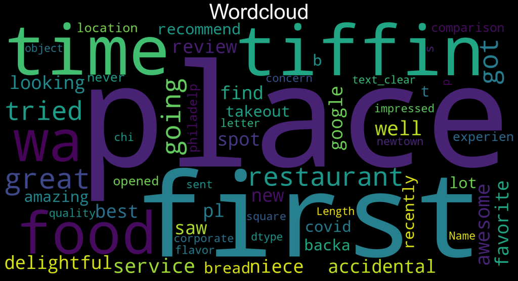

```python
foodpen_reviews_in_top15 = pd.merge(foodpen_reviews, foodpen_in_top_15, how='right', on='business_id')
wc = WordCloud(width=1600, height=800, random_state=1, max_words=200000000)
wc.generate(str(foodpen_reviews_in_top15['text_clear']))
plt.figure(figsize=(20,10), facecolor='k')
plt.title("Wordcloud", fontsize=40,color='white')
plt.imshow(wc, interpolation='bilinear')
plt.axis('off')
plt.tight_layout(pad=10)
plt.show()
```

**Map Location**

```python
m_1 = folium.Map(location=[39.9527237, -75.1635262], tiles='cartodbpositron', zoom_start=9)

# Add points to the map
mc = MarkerCluster()
for idx, row in foodpen_in.iterrows():
    if not math.isnan(row['longitude']) and not math.isnan(row['latitude']):
        mc.add_child(Marker([row['latitude'], row['longitude']]))
m_1.add_child(mc)

title_html = '''
             <h3 align="center" style="font-size:20px"><b>Indian restaurants distribution in Pennsylvania</b></h3>
             '''
m_1.get_root().html.add_child(folium.Element(title_html))

# Display the map
m_1
```

Make this Notebook Trusted to load map: File -> Trust Notebook

[interactive chart not shown]

# Business Model.

#### Restaurant Filtering System.

```python
def find_restaurants(city, cuisine):
    # Select rows where the specified cuisine is present in any of the 'category' columns
    goodcuisine = good_food[(good_food['category1']).str.contains(cuisine) | (good_food['category2'])\
                         .str.contains(cuisine) |
                           (good_food['category3']).str.contains(cuisine) | (good_food['category4'])\
                         .str.contains(cuisine) |
                           (good_food['category5']).str.contains(cuisine) | (good_food['category6'])\
                         .str.contains(cuisine) |
                           (good_food['category7']).str.contains(cuisine) | (good_food['category8'])\
                         .str.contains(cuisine) |
                           (good_food['category9']).str.contains(cuisine) | (good_food['category10'])\
                         .str.contains(cuisine)]

    # Sort the resulting DataFrame by the 'spm' column in descending order and select the top 10 rows
    final = goodcuisine[['name', 'address', 'Monday', 'Tuesday','Wednesday', 'Thursday',
                         'Friday', 'Saturday', 'Sunday', 'senti_polarity', 'longitude', 'latitude']]
    f1 = final.sort_values('senti_polarity', axis=0, ascending=False).head(10)




    # Return the resulting DataFrame
    return f1
```

```python
def filtering_system(city, cuisine):

    restaurants = find_restaurants(city, cuisine)

# Create the map
    m = folium.Map(location=[39.9527237, -75.1635262], tiles='cartodbpositron', zoom_start=9)

    # Add points to the map
    mc = MarkerCluster()
    for idx, row in restaurants.iterrows():
        if not math.isnan(row['longitude']) and not math.isnan(row['latitude']):
            mc.add_child(Marker([row['latitude'], row['longitude']], popup=row['name']))
    m.add_child(mc)

# Add a title to the map
    title_html = '''
             <h3 align="center" style="font-size:20px"><b>Top selected restaurants in the city</b></h3>
             '''
    m.get_root().html.add_child(folium.Element(title_html))

    # Display the map
    return(m)
```

```python
# in order to use the system:
    # Where it says 'Philadelphia', please write the name of the city with the first letter in capitals.
    # Where it says 'japansese', please write the type of cuisine you wish to search, with every letter in minors.
filtering_system('Philadelphia', 'japanese')
```

Make this Notebook Trusted to load map: File -> Trust Notebook

[interactive chart not shown]